# Lesson 160 · Year 4 exit exam

Standalone CPU evidence audit. Tier B saved real RelBench predictions; synthetic fixtures are explicitly labeled. Three TODO functions drive the actual assessment. No fresh training or learner completion is inferred. Course links may remain unavailable until publication; all computation inputs are embedded.

**Exam package** · [Student notebook](https://avistian.github.io/relational/labs/0160-year-4-exit-exam.ipynb) · [Executed author preview](https://avistian.github.io/relational/labs/html/0160-year-4-exit-exam.html) · [Author solution](https://avistian.github.io/relational/labs/solutions/0160-year-4-exit-exam.ipynb) · [Open in Colab](https://colab.research.google.com/github/avistian/relational/blob/main/labs/0160-year-4-exit-exam.ipynb)  
Jump to tasks · [Printable reference](https://avistian.github.io/relational/reference/year-4-exit-exam.html) · [Submission template](https://avistian.github.io/relational/labs/l160-submission.md) · [Measured evidence](https://avistian.github.io/relational/labs/evidence/l160/report.md) · [Reproduction and remediation](https://avistian.github.io/relational/labs/l160-reproduction.md)

## 1 · The decision you must defend

**Reading route.** Read the coverage → align predictions → check effort and temporal evidence → apply every gate → defend the decision.

**Single win:** decide whether a RelBench portfolio meets the Year 4 exit requirements, and identify exactly which observations would change that decision. Read this guide in about 15 minutes; allocate separate sessions for coding and your written defense. Closing the missing experiments is additional work.

[Lesson 158](https://avistian.github.io/relational/lessons/0158-year-4-synthesis.html) turned evidence into a bounded thesis argument. [Lesson 159](https://avistian.github.io/relational/lessons/0159-foundation-model-preview.html) showed why reconstruction performance alone cannot establish transfer to another database. This exam asks you to apply that same discipline to your own portfolio. Neither a promising foundation-model vision nor an executed reference notebook waives the Year 4 requirements.

The [curriculum](https://avistian.github.io/relational/reference/curriculum.html#y4) requires documented results versus manual feature engineering on at least three tasks, accuracy and human-effort comparisons, a passed temporal-leakage audit, and honest failure cases. A **task** is one database prediction problem, such as predicting a driver's finishing position at a specified cutoff. Five seeds are five fits of the same task. A **matched comparison** evaluates both methods on the same query population under a declared, comparable protocol.

**A negative result is admissible.** The exit does not require RDL to win. It requires a complete, credible comparison and a defensible explanation. This serves the mission: know what the relational models can establish before publishing a claim.

## 2 · Read the evidence before giving a grade

**Executed author evidence:** 98,918 saved prediction rows rescored; 45 validation decisions checked; 226 frozen inputs. **Replay PASS · Year 4 exit INCOMPLETE · learner PENDING_WRITTEN_DEFENSE.**

| Task | Test experiment | Matched FE | Human effort | Temporal sign-off |
| --- | --- | --- | --- | --- |
| rel-trial/study-outcome | COMPLETE | NOT_RUN | NOT_OBSERVED | NOT_ESTABLISHED |
| rel-f1/driver-position | COMPLETE | COMPLETE | NOT_OBSERVED | NOT_ESTABLISHED |
| rel-trial/site-sponsor-run | INCOMPLETE | NOT_RUN | NOT_OBSERVED | NOT_ESTABLISHED |

The three declared tasks span two databases. The classification and regression reference experiments each have five completed seeds. Recommendation has a validation-only pilot and zero completed test seeds. L155 adds the matched F1 feature-engineering comparison. The other FE comparisons are missing. [Frozen report](https://avistian.github.io/relational/labs/evidence/l160/report.md).

The complete selected replay covers L151–L158's declared numerical evidence: classification reference and validation-selected lanes remain separate; L152 supplies regression; L153 contributes only its validation pilot; L155 supplies paired FE/RDL errors; L156/L157 supply temporal experiments. L154 and L158 are report views of these experiments. L159's synthetic mechanism adds no real benchmark task.

> **Scope check.** Replay verifies saved predictions, selection histories and frozen file identities. SQL reconstruction, neighborhood audits and historical availability conclusions are inherited from pinned upstream artifacts. No new model is fitted. Whole-paper reproduction and the original human study remain NOT_RUN. Missing arrival histories and source nonfinite-gradient observations remain unresolved.

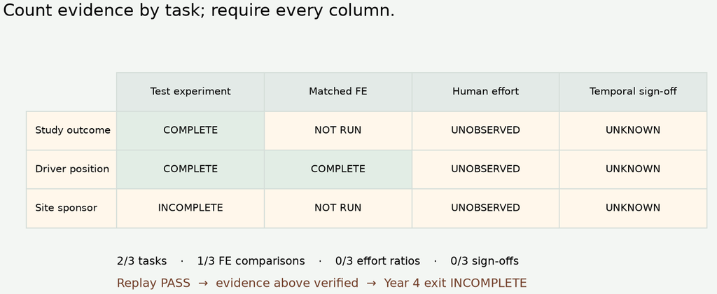

Measured author evidence: two completed tasks, one matched FE comparison, unobserved human effort and unestablished temporal sign-offs. Each missing column blocks the exit.

**Trace question.** Which cell changes if you add five more F1 training seeds? No new task or missing observation appears. Which cell changes if you finish recommendation training? Its test-experiment cell changes; FE, human effort and temporal review still need their own evidence.

## 3 · Recover the comparison from query identities

A **query key** is `(entity_id, cutoff)`. The same driver can appear at several cutoffs. Aligning by driver alone loses that distinction; aligning by row position assumes the storage order is meaningful.

**Worked example — synthetic, for hand calculation.** Truth keys are `(7,10), (7,20), (8,10)` with targets `1,3,5`. FE predictions are stored in reverse key order as `7,4,1`; RDL predictions are stored in truth order as `2,5,5`. Join both packets onto the truth keys first. FE absolute errors are `0,1,2`; RDL errors are `1,2,0`. The per-query benefit `FE error − RDL error` is `−1,−1,+2`, averaging zero. Row-wise subtraction before joining gives a different and invalid comparison.

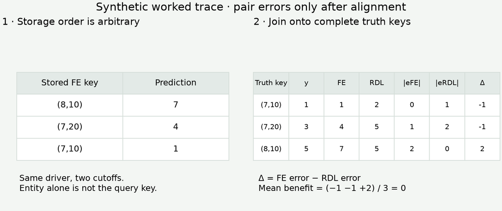

Synthetic trace, not a benchmark result. Reverse-stored FE predictions are joined by entity and cutoff before computing absolute errors and benefits.

For MAE, define benefit as `FE MAE − RDL MAE`, in finishing positions: positive favors RDL. AUROC and MAP are higher-is-better metrics, so their analogous benefit uses `RDL score − FE score`. Never average raw AUROC, MAE and MAP into one portfolio score. [RelBench Tables 6–8](https://arxiv.org/html/2407.20060v1#A2.SS1).

**Actual L155 result.** FE test MAE is **3.948917**, basic RDL is **4.013141**, and benefit is **−0.064225** positions. The conditional driver-bootstrap 95% interval is **[−0.312329, +0.172961]**. These values are rounded independently from the underlying scores. The point estimate favors FE; the interval does not settle direction. Neither superiority nor equivalence is established. The interval resamples drivers while keeping their cutoff queries together, conditional on the fitted models and this test split. It does not cover common race/time dependence, training uncertainty or new databases. [L155 protocol](https://avistian.github.io/relational/labs/l155-reproduction.md).

## 4 · Keep the human clock and the validity audit separate

**Human effort** means active human work within a declared scope. Record it prospectively: log work as it occurs. The comparison here is `FE active minutes / RDL active minutes`. A ratio of three means FE required three times the recorded active work for that task and scope; it says nothing by itself about model quality.

**Worked example — synthetic.** FE build/debug/validation takes 90 active minutes and RDL takes 30: the ratio is 3. If neither arm was timed, the ratio is NOT_OBSERVED. If RDL has zero recorded minutes, division is undefined; it is not evidence of unlimited savings. Machine runtime and shared infrastructure belong in separate records. Missing logs cannot be repaired by assigning remembered durations.

The [RelBench expert-user study](https://arxiv.org/html/2407.20060v1#S6) supplies published context. Replaying its released SQL features does not reproduce the expert's human work. Use [the prospective log template](https://avistian.github.io/relational/labs/l160-effort-template.json) for a newly declared effort study. One person's timing remains conditional on experience, tool support, scope and order of work; disclose assistance and reused infrastructure.

**Temporal sign-off** is a reviewed audit conclusion under a stated information policy. It must address query-owned context, feature arrival, target maturity at fitting, preprocessing scope and validation-only selection. A clean event-time check addresses one of those questions. L156/L157's correction changes the fitting horizon but leaves historical feature availability NOT_ESTABLISHED. Preserve that status; a green replay cannot turn it into PASS. [Temporal audit](https://avistian.github.io/relational/labs/l156-reproduction.md).

## 5 · Apply every gate

> **In plain terms.** Each requirement needs its own evidence. Extra success in one column cannot pay for a missing column.

The exam checks every task in your declared portfolio, with at least three distinct tasks. Freeze that inclusion rule before comparing test scores. The task, FE, effort and temporal gates all apply to the same declared entries. You cannot silently remove a difficult fourth task after seeing its result. A justified new portfolio definition requires a documented new protocol.

Predict: does completing the third test experiment also supply its FE comparison, effort logs and temporal audit? Explain before reading further.

Counterfactual: add a third test experiment, then matched FE, effort logs, temporal sign-offs and actual review. At which step can every gate pass? These additions are hypothetical.

**Intervention exercise.** Predict the outcome, then complete the third task in the scenario. Next add both missing FE comparisons. Next add observed effort and temporal sign-offs. Finally add reviewer approval. Watch which gates change. These are hypothetical evidence additions; they do not edit the measured report or claim that the work has happened.

**Honest failures** include observed underperformance, incomplete experiments and audit limitations with concrete evidence links. The supplied author packet documents these, so its failure-disclosure gate passes. The overall exit is still INCOMPLETE; the learner defense remains PENDING_WRITTEN_DEFENSE. The machine checks declarations. A reviewer checks whether the cited evidence warrants them.

## 6 · Implement the decision

The standalone notebook embeds the frozen inputs. Python 3.10+ and NumPy suffice for replay; it downloads no datasets, trains no models and runs on CPU. PROVIDED sections show all replay/assessment implementations in coherent cells. The current lesson introduces no new neural architecture; the upstream model/trainer links remain in the reproduction protocol.

1. **TODO — `aligned_losses`.** Validate unique, complete query keys and finite values; join both prediction packets onto the truth order; calculate paired absolute errors and signed benefits. CHECK permutes storage order and rejects duplicates, missing queries and NaNs. The real replay invokes your function on all five FE/RDL seed pairs, both splits.
2. **TODO — `observed_effort`.** Validate prospective active-human records, task identity and comparable scope; aggregate per arm; preserve missing, incomplete and zero-denominator states. CHECK uses synthetic logs. The real evidence has no observations and must return NOT_OBSERVED.
3. **TODO — `exit_gates`.** Count unique declared tasks, require all evidence gates and keep the human review separate. CHECK injects a validation pilot, duplicate task, unobserved effort and an unestablished audit. Even a perfect rubric cannot compensate for missing experiments.

**EXIT output:** export `l160-submission.json` with your replay report and written defense, using the [submission template](https://avistian.github.io/relational/labs/l160-submission.md). Leave reviewer scores unset until the teaching agent reviews the defense. The author solution demonstrates computational behavior; its short example is not a completed learner essay.

## 7 · Defend the decision and close the gaps

Write **700–1,000 words**: state your verdict; trace one saved result through its query keys and selection rule; compare FE/RDL with the right units and uncertainty; explain effort and temporal limitations; propose a costed, falsifiable next experiment. Cite one unfavorable or incomplete result. Explain why L159's reconstruction result cannot fill a portfolio slot.

| Review axis | 0 — missing or incorrect | 1 — partly supported | 2 — supported and explicit |
| --- | --- | --- | --- |
| Provenance and task coverage | Counts reports as tasks | Correct counts, weak trace | Keys, lanes, seeds and hashes traced |
| Comparator and metric | Unmatched or wrong direction | Fair comparison, missing units | Matched population, units and direction |
| Uncertainty and failure cases | Conceals failure or overclaims | Limits named, weak interpretation | Conditional uncertainty and counter-evidence explained |
| Effort and temporal validity | Invents effort or certifies unknowns | Gaps recognized | Measurement plan and policy scope operational |
| Next experiment and verdict | Untestable claim or false pass | Test sketched | Frozen selection, cutoff, budget and disconfirming result |

**Same total, different decision.** These hypothetical reviews illustrate the rule; they are not grades for your submission:

| Experimental gates | Five rubric scores | Decision |
| --- | --- | --- |
| All met | Not reviewed | Defense pending |
| All met | 2, 2, 2, 2, 0 | Revision required |
| All met | 2, 2, 2, 1, 1 | Pass |
| One missing | 2, 2, 2, 2, 2 | Incomplete |

Both middle rows total eight, but a zero leaves one essential reasoning dimension unsupported. In the final row, strong prose cannot supply a missing experiment. **Try it:** improve the zero to one in the second row. **Check:** the total becomes nine, every axis is positive, and the decision becomes PASS if every experimental gate is still met and an actual reviewer supplied the scores.

Reviewed readiness requires **at least 8/10 with no zero**, plus all experimental gates. A prose revision and an incomplete portfolio are different states. Ask the teaching agent to assess your reasoning and any unclear mechanism; automatic code checks do not grade scientific judgment.

**Remediation order.** First resolve the information-policy/arrival-history requirements with a reviewable audit design. Plan prospective effort observation before doing more work. Then scope the missing FE and third-task experiments, pin their recipes and budget all seeds, preparation, validation and retries. L153's previous safety-adjusted forecast was **$51.85**, above its $10 cap; it remains stopped. Do not reduce epochs, seeds or catalog size while retaining the label “full reproduction.” [Exact commands, inherited recipes and current stop condition](https://avistian.github.io/relational/labs/l160-reproduction.md).

Explain replay PASS versus exit INCOMPLETE; ask the teaching agent to review your reasoning.

**Spaced retrieval.** Tomorrow, reconstruct the five evidence gates from memory. In one week, review a fresh portfolio whose best score comes from a validation pilot: identify the unsupported claim before looking at the checklist. Year 5 reading can follow the roadmap, but the Year 4 exit record remains pending until its requirements are met.

## Primary reading

Read [Robinson et al., RelBench v1, Section 6 and Appendix C](https://arxiv.org/html/2407.20060v1#S6) alongside [Tables 6–8](https://arxiv.org/html/2407.20060v1#A2.SS1). Annotate which comparisons are basic RDL, boosted regression, raw-table trees and manual FE. The L155 basic-GNN comparison does not reproduce Figure 3's boosted regression head. Bring one claim/evidence mismatch to your follow-up with the teaching agent.

```python
# @colab-bootstrap — PROVIDED: Python3.10+ and numpy; no downloads or training.
import base64,copy,gzip,hashlib,json,math,statistics,zlib
from datetime import datetime
from pathlib import Path
import numpy as np
ROOT=Path('l160-packet')
ROOT.mkdir(exist_ok=True)
```

[output not shown]

## PROVIDED · Complete seed sets and comparable scores

Established replay code is visible here. Trace the keys, seed and selection checks. These functions perform saved-evidence analysis; the original model/trainer is linked in the reproduction contract.

```python
def summarize_runs(records, expected_seeds, contract):
    """Aggregate one exact local lane; missing runs are errors, never zeros."""
    fields = ('task','metric','unit','direction','split','population','protocol',
              'lane','epochs','n_queries','origin','evaluation')
    if any(k not in contract for k in fields):
        raise ValueError('Incomplete contract')
    if contract['origin'] != 'LOCAL' or contract['n_queries'] <= 0 or contract['epochs'] <= 0:
        raise ValueError('Expected a positive-sized local experiment')
    allowed = {'AUROC':('fraction','higher'), 'MAP@10':('fraction','higher'),
               'MAE':('position','lower')}
    if allowed.get(contract['metric']) != (contract['unit'],contract['direction']):
        raise ValueError('Metric, unit and direction disagree')
    seeds = [r.get('seed') for r in records]
    if len(expected_seeds)<2 or len(set(expected_seeds))!=len(expected_seeds):
        raise ValueError('Declare at least two distinct seeds for sample SD')
    if len(seeds)!=len(set(seeds)) or set(seeds)!=set(expected_seeds):
        raise ValueError('Missing, duplicate or extra seed')
    for row in records:
        if row.get('status')!='COMPLETE' or any(row.get(k)!=contract[k] for k in fields):
            raise ValueError('Incomplete run or mixed contract')
        value = row.get('score')
        if not isinstance(value,(int,float)) or not math.isfinite(value) or value<0:
            raise ValueError('Invalid metric')
        if contract['metric']!='MAE' and value>1:
            raise ValueError('Store AUROC/MAP as fractions, not percentages')
    scores = [r['score'] for r in records]
    return dict(contract,status='COMPLETE',seeds=sorted(seeds),n_seeds=len(seeds),
                mean=statistics.mean(scores),sample_sd=statistics.stdev(scores))
```

```python
def compare_entries(model, baseline):
    """Orient a within-task difference; paper context cannot establish local wins."""
    for key in ('task','metric','unit','direction','split'):
        if key not in model or model[key]!=baseline.get(key):
            raise ValueError('Incompatible '+key)
    for row in (model,baseline):
        if row.get('status')!='COMPLETE' or row.get('origin') not in ('LOCAL','PUBLISHED'):
            raise ValueError('Comparison requires completed, labeled evidence')
        value=row.get('mean')
        if not isinstance(value,(int,float)) or not math.isfinite(value) or value<0:
            raise ValueError('Invalid comparison metric')
        if row['metric'] in ('AUROC','MAP@10') and (row['unit']!='fraction' or value>1):
            raise ValueError('Invalid metric scale')
    if model['direction'] not in ('higher','lower'):
        raise ValueError('Unknown metric direction')
    local = model['origin']==baseline['origin']=='LOCAL'
    if local and (not model.get('evaluation') or model['evaluation']!=baseline.get('evaluation')):
        raise ValueError('Local comparators need identical evaluation protocols')
    if local and (not model.get('population') or model['population']!=baseline.get('population')):
        raise ValueError('Local comparators need identical query population')
    gap = (model['mean']-baseline['mean'])*(1 if model['direction']=='higher' else -1)
    return dict(task=model['task'],oriented_gap=gap,unit=model['unit'],
                relative_percent=100*gap/baseline['mean'] if baseline['mean'] else None,
                scope='LOCAL_MATCHED_DESCRIPTIVE' if local else 'PUBLISHED_CONTEXT_ONLY',
                winner=('MODEL' if gap>0 else 'BASELINE' if gap<0 else 'TIE') if local else 'NOT_ESTABLISHED')
```

```python
def portfolio_verdict(entries, comparisons, required_tasks):
    """Count task coverage once; absent comparisons prevent a superiority claim."""
    tasks=[e['task'] for e in entries]
    if not required_tasks or len(set(required_tasks))!=len(required_tasks):
        raise ValueError('Required tasks must be unique and nonempty')
    if len(tasks)!=len(set(tasks)) or not set(tasks)<=set(required_tasks):
        raise ValueError('Duplicate or undeclared task')
    if any(e.get('origin')!='LOCAL' or e.get('split')!='test' or
           e.get('status') not in ('COMPLETE','INCOMPLETE','NOT_RUN') for e in entries):
        raise ValueError('Coverage requires local test entries with explicit status')
    complete={e['task'] for e in entries if e['status']=='COMPLETE'}
    compared=[c['task'] for c in comparisons]
    if len(compared)!=len(set(compared)) or not set(compared)<=complete:
        raise ValueError('Duplicate comparison or incomplete task compared')
    if any(c.get('scope') not in ('LOCAL_MATCHED_DESCRIPTIVE','PUBLISHED_CONTEXT_ONLY') for c in comparisons):
        raise ValueError('Unknown comparison scope')
    matched=[c for c in comparisons if c['scope']=='LOCAL_MATCHED_DESCRIPTIVE']
    if any(c.get('winner') not in ('MODEL','BASELINE','TIE') for c in matched):
        raise ValueError('Invalid matched comparison')
    all_covered=complete==set(required_tasks)
    all_wins=all_covered and len(matched)==len(required_tasks) and all(c['winner']=='MODEL' for c in matched)
    return dict(complete_tasks=len(complete),required_tasks=len(required_tasks),
                missing_tasks=sorted(set(required_tasks)-complete),
                benchmark_coverage='COMPLETE' if all_covered else 'INCOMPLETE',
                matched_baseline_tasks=len(matched),
                local_superiority='DESCRIPTIVE_WINS_ON_SELECTED_TASKS' if all_wins else 'NOT_ESTABLISHED',
                aggregate_metric='NOT_DEFINED_ACROSS_METRIC_FAMILIES',
                learner='PENDING_WRITTEN_DEFENSE')
```

## PROVIDED · Paired errors and human-effort scope

Established replay code is visible here. Trace the keys, seed and selection checks. These functions perform saved-evidence analysis; the original model/trainer is linked in the reproduction contract.

```python
def paired_losses(queries, fe_predictions, rdl_predictions):
    """Align by the complete query key. Positive benefit favors RDL."""
    def keyed(rows,value):
        result={}
        for row in rows:
            key=(row['entity'],row['time']);v=float(row[value])
            if key in result or not math.isfinite(v):raise ValueError('Duplicate query or nonfinite value')
            result[key]=v
        return result
    truth=keyed(queries,'target');fe=keyed(fe_predictions,'prediction');rdl=keyed(rdl_predictions,'prediction')
    if not truth or set(truth)!=set(fe) or set(truth)!=set(rdl):raise ValueError('Full query populations must match')
    rows=[]
    for (entity,time),y in truth.items():
        f=abs(y-fe[(entity,time)]);g=abs(y-rdl[(entity,time)])
        rows.append(dict(entity=entity,time=time,fe_loss=f,rdl_loss=g,benefit=f-g))
    n=len(rows)
    return dict(n=n,fe_mae=sum(r['fe_loss'] for r in rows)/n,rdl_mae=sum(r['rdl_loss'] for r in rows)/n,
                benefit_mae=sum(r['benefit'] for r in rows)/n,rows=rows)
```

```python
def summarize_effort(sessions, task, participant, assistance, coverage):
    """Count human marginal time separately from shared setup and machine time."""
    if not task or not participant or not assistance:raise ValueError('Declare task, participant and assistance')
    if set(coverage)!={'FE','RDL'} or any(v not in {'complete','partial','not_observed'} for v in coverage.values()):raise ValueError('Explicit method coverage required')
    marginal=dict(FE=0.,RDL=0.);shared=dict(FE=0.,RDL=0.);machine=dict(FE=0.,RDL=0.)
    seen=set();human_intervals=[];observed=set()
    for s in sessions:
        if not s.get('id') or s['id'] in seen:raise ValueError('Distinct session IDs required')
        seen.add(s['id'])
        if (s.get('task'),s.get('participant'),s.get('assistance'))!=(task,participant,assistance):raise ValueError('Mixed task, participant or assistance policy')
        method=s.get('method');kind=s.get('kind');scope=s.get('scope')
        if method not in marginal or kind not in {'human','machine'} or scope not in {'marginal','shared'} or not s.get('phase'):raise ValueError('Invalid session contract')
        try:
            start=datetime.fromisoformat(s['start']);end=datetime.fromisoformat(s['end'])
            if start.utcoffset() is None or end.utcoffset() is None or end<=start:raise ValueError('Closed positive interval with timezone required')
        except (KeyError,TypeError):raise ValueError('Closed timestamp interval required')
        hours=(end-start).total_seconds()/3600
        if kind=='human':
            if any(start<b and a<end for a,b in human_intervals):raise ValueError('Overlapping active human sessions')
            human_intervals.append((start,end))
            (marginal if scope=='marginal' else shared)[method]+=hours
            if scope=='marginal':observed.add(method)
        else:machine[method]+=hours
    for method,status in coverage.items():
        if status=='complete' and method not in observed:raise ValueError('Complete effort requires observed marginal human sessions')
        if status=='not_observed' and method in observed:raise ValueError('Observed sessions conflict with missingness')
        if method not in observed:marginal[method]=None
    return dict(task=task,participant=participant,assistance=assistance,coverage=dict(coverage),
                human_marginal_hours=marginal,human_shared_hours=shared,machine_hours=machine,
                interpretation='Descriptive logged effort; completeness is self-attested; order and experience are not controlled')
```

```python
def effort_ratio(summary):
    """Ratio needs two complete comparable human logs and a positive denominator."""
    hours=summary['human_marginal_hours']
    for value in hours.values():
        if value is not None and (not math.isfinite(value) or value<0):raise ValueError('Finite nonnegative human hours required')
    if any(v!='complete' for v in summary['coverage'].values()):
        return dict(status='NOT_OBSERVED' if all(v=='not_observed' for v in summary['coverage'].values()) else 'INCOMPLETE',ratio=None,reduction_percent=None)
    fe=hours['FE'];rdl=hours['RDL']
    if fe is None or rdl is None:return dict(status='NOT_OBSERVED',ratio=None,reduction_percent=None)
    if rdl==0 or fe==0:return dict(status='UNDEFINED_ZERO_TIME',ratio=None,reduction_percent=None)
    return dict(status='OBSERVED_DESCRIPTIVE',ratio=fe/rdl,reduction_percent=100*(1-rdl/fe))
```

## PROVIDED · Original portfolio replay

Established replay code is visible here. Trace the keys, seed and selection checks. These functions perform saved-evidence analysis; the original model/trainer is linked in the reproduction contract.

```python
def aligned_score(truth_keys, targets, prediction_keys, predictions, metric, catalog=None):
    truth_keys=[tuple(map(int,k)) for k in truth_keys]
    prediction_keys=[tuple(map(int,k)) for k in prediction_keys]
    if (not truth_keys or len(set(truth_keys))!=len(truth_keys) or
        len(set(prediction_keys))!=len(prediction_keys) or set(truth_keys)!=set(prediction_keys) or
        len(targets)!=len(truth_keys) or len(predictions)!=len(prediction_keys)):
        raise ValueError('Missing, duplicate or mismatched query keys')
    index={k:i for i,k in enumerate(prediction_keys)}
    pred=np.asarray(predictions)[[index[k] for k in truth_keys]]
    if not np.isfinite(pred).all():
        raise ValueError('Nonfinite predictions')
    if metric=='MAP@10':
        if pred.ndim!=2 or pred.shape[1]<1 or not catalog:
            raise ValueError('Missing candidate protocol')
        if not np.issubdtype(pred.dtype,np.integer) or pred.min()<0 or pred.max()>=catalog:
            raise ValueError('Invalid candidate identity')
        if any(len(set(row))!=len(row) for row in pred.tolist()):
            raise ValueError('Duplicate recommendations')
        values=[]
        for positives,ranking in zip(targets,pred.tolist()):
            relevant=set(positives)
            if not relevant or min(relevant)<0 or max(relevant)>=catalog:
                raise ValueError('Invalid relevance set')
            hits=0;total=0.
            for rank,item in enumerate(ranking,1):
                if item in relevant:
                    hits+=1;total+=hits/rank
            values.append(total/min(len(relevant),len(ranking)))
        return float(np.mean(values))
    y=np.asarray(targets,dtype=float)
    if pred.ndim!=1 or y.ndim!=1 or not np.isfinite(y).all():
        raise ValueError('Invalid scalar labels or predictions')
    if metric=='MAE':
        return float(np.mean(np.abs(pred.astype(float)-y)))
    if metric=='AUROC':
        if set(y.tolist())!={0.,1.}:
            raise ValueError('AUC requires both binary classes')
        order=np.argsort(pred,kind='stable');ranks=np.empty(len(pred),dtype=float)
        start=0
        while start<len(order):
            stop=start+1
            while stop<len(order) and pred[order[stop]]==pred[order[start]]:
                stop+=1
            ranks[order[start:stop]]=(start+1+stop)/2
            start=stop
        npos=int(y.sum());nneg=len(y)-npos
        return float((ranks[y==1].sum()-npos*(npos+1)/2)/(npos*nneg))
    raise ValueError('Unsupported metric')
```

```python
def verify_inputs(root, manifest):
    root=Path(root).resolve()
    if not manifest.get('files'):
        raise ValueError('Empty input manifest')
    for relative,digest in manifest['files'].items():
        path=(root/relative).resolve()
        if not path.is_relative_to(root) or not path.is_file():
            raise ValueError('Missing or unsafe input: '+relative)
        if hashlib.sha256(path.read_bytes()).hexdigest()!=digest:
            raise ValueError('Changed frozen input: '+relative)
    return len(manifest['files'])
```

```python
def replay(root, manifest, summarize=summarize_runs, compare=compare_entries, verdict=portfolio_verdict):
    """Recompute every saved split in each selected evidence lane, without refitting."""
    root=Path(root);verified=verify_inputs(root,manifest)
    def read(name):
        return json.loads((root/name).read_text())
    def keys(z,split,entity):
        return list(zip(map(int,z[split+'_'+entity]),map(int,z[split+'_time'])))
    def population(ks):
        return hashlib.sha256(json.dumps(sorted(ks),separators=(',',':')).encode()).hexdigest()
    def close(a,b):
        if abs(a-b)>1e-12:
            raise ValueError('Saved score disagrees with replay')
    counts={};summaries={};runs={};selection_checks=0
    base='evidence/l151';truth=np.load(root/base/'prepared/queries.npz',allow_pickle=False)
    frozen=read(base+'/frozen.json')
    if frozen['test_access'] or frozen['lr']!=max(frozen['candidates'],key=lambda x:(x['selection_auc'],-x['lr']))['lr']:
        raise ValueError('Invalid validation selection')
    ph=manifest['files']['sources/l151/protocol.json']
    for lane,prefix,seeds in [('reference','ref-',list(range(5))),('selected','selected-',list(range(10,15)))]:
        bucket={s:[] for s in ['val','test']};counts['l151_'+lane]=0
        for seed in seeds:
            directory=base+'/'+prefix+str(seed);r=read(directory+'/result.json')
            if (r['status']!='COMPLETE' or r['track']!=lane or r['seed']!=seed or
                r['epochs']!=20 or len(r['history'])!=20 or r['lr']!=frozen['lr']):
                raise ValueError('L151 incomplete or mixed lane')
            if r['best_epoch']!=1+int(np.argmax([h['val']['roc_auc'] for h in r['history']])):
                raise ValueError('L151 checkpoint selection')
            if r['temporal_audit']['future_violations']!=0:
                raise ValueError('Observed temporal violation')
            selection_checks+=1
            z=np.load(root/directory/'predictions.npz',allow_pickle=False)
            for split in bucket:
                tk=keys(truth,split,'study');pk=keys(z,split,'study')
                target_by_key=dict(zip(tk,truth[split+'_target'].tolist()))
                if any(target_by_key.get(k)!=float(y) for k,y in zip(pk,z[split+'_target'])):
                    raise ValueError('Classification target mismatch')
                score=aligned_score(tk,truth[split+'_target'],pk[::-1],z[split+'_pred'][::-1],'AUROC')
                close(score,r['scores'][split]['roc_auc']);counts['l151_'+lane]+=len(tk)
                contract=dict(task='rel-trial/study-outcome',metric='AUROC',unit='fraction',direction='higher',
                              split=split,population=population(tk),protocol=ph,lane=lane,epochs=20,
                              n_queries=len(tk),origin='LOCAL',evaluation='full-split-keyed-scalar')
                bucket[split].append(dict(contract,seed=seed,status='COMPLETE',score=score))
        runs['classification_'+lane]=bucket
        summaries['classification_'+lane]={s:summarize(rows,seeds,{k:v for k,v in rows[0].items() if k not in ('seed','status','score')}) for s,rows in bucket.items()}
    base='evidence/l152';truth=np.load(root/base/'paper/seed-0/predictions.npz',allow_pickle=False)
    labels=read(base+'/label-audit.json')
    if labels['status']!='PASS' or labels['independently_rebuilt_labels']!=8712:
        raise ValueError('Missing upstream label audit')
    bucket={s:[] for s in ['val','test']};counts['l152_reference']=0
    protocol=read('sources/l152/protocol.json');ph=manifest['files']['sources/l152/protocol.json']
    for seed in range(5):
        directory=base+'/paper/seed-'+str(seed);r=read(directory+'/result.json');done=read(directory+'/completed.json')
        if (done['status']!='COMPLETE' or done['seed']!=seed or r['seed']!=seed or
            r['epochs']!=10 or len(r['trace'])!=10 or r['protocol']!={
                'channels':protocol['channels'],'num_layers':protocol['layers'],
                'batch_size':protocol['batch_size'],'lr':protocol['lr'],'epochs':protocol['epochs'],
                'fanout':protocol['fanouts'],'aggr':protocol['aggr'],'temporal_strategy':'uniform'}):
            raise ValueError('L152 incomplete or changed recipe')
        if r['selected_epoch']!=min(r['trace'],key=lambda row:row['val_mae'])['epoch']:
            raise ValueError('L152 selection not first validation minimum')
        if read(directory+'/temporal-audit.json')['status']!='PASS':
            raise ValueError('Missing temporal audit')
        selection_checks+=1;z=np.load(root/directory/'predictions.npz',allow_pickle=False)
        for split in bucket:
            tk=keys(truth,split,'entity');pk=keys(z,split,'entity')
            target_by_key=dict(zip(tk,truth[split+'_target'].tolist()))
            if any(target_by_key.get(k)!=float(y) for k,y in zip(pk,z[split+'_target'])):
                raise ValueError('Regression target mismatch')
            if (hashlib.sha256(np.asarray(tk,dtype='<i8').tobytes()).hexdigest()!=labels['query_key_hashes'][split] or
                len(tk)!=labels['counts'][split]):
                raise ValueError('Regression population mismatch')
            score=aligned_score(tk,truth[split+'_target'],pk[::-1],z[split+'_pred'][::-1],'MAE')
            close(score,r['scores'][split]);counts['l152_reference']+=len(tk)
            contract=dict(task='rel-f1/driver-position',metric='MAE',unit='position',direction='lower',
                          split=split,population=population(tk),protocol=ph,lane='reference',epochs=10,
                          n_queries=len(tk),origin='LOCAL',evaluation='full-split-keyed-scalar')
            bucket[split].append(dict(contract,seed=seed,status='COMPLETE',score=score))
    runs['regression_reference']=bucket
    summaries['regression_reference']={s:summarize(rows,list(range(5)),{k:v for k,v in rows[0].items() if k not in ('seed','status','score')}) for s,rows in bucket.items()}
    base='evidence/l153';r=read(base+'/pilot/result.json');z=np.load(root/base/'pilot/predictions.npz',allow_pickle=False)
    truth=json.loads(gzip.decompress((root/base/'prepared/val-truth.json.gz').read_bytes()))
    if r['status']!='PARTIAL_TIMING_PILOT' or set(r['scores'])!={'val'} or any(k.startswith('test') for k in z.files):
        raise ValueError('Recommendation packet must remain a validation pilot')
    if r['protocol_hash']!=manifest['files']['sources/l153/protocol.json'] or z['val_pred'].shape!=(37003,10):
        raise ValueError('Changed ranking protocol')
    score=aligned_score([(t['entity'],t['time']) for t in truth],[t['positives'] for t in truth],
                        keys(z,'val','entity')[::-1],z['val_pred'][::-1],'MAP@10',53241)
    close(score,r['scores']['val']);counts['l153_pilot']=len(truth)
    incomplete=dict(task='rel-trial/site-sponsor-run',metric='MAP@10',unit='fraction',direction='higher',
                    split='test',population='NOT_EVALUATED',protocol=r['protocol_hash'],lane='reference',
                    epochs=20,n_queries=27428,origin='LOCAL',evaluation='full-catalog:53241@10',status='INCOMPLETE',n_seeds=0,
                    mean=None,sample_sd=None)
    pilot=dict(task=incomplete['task'],split='val',status='PARTIAL_TIMING_PILOT',mean=score,
               n_queries=len(truth),catalog=53241,training_batches=32,seed=0)
    entries=[summaries['classification_reference']['test'],summaries['regression_reference']['test'],incomplete]
    context=read('evidence/l154/published-context.json');comparisons=[];paper_replay=[]
    for entry in entries:
        if entry['status']!='COMPLETE':
            continue
        row=context['tasks'][entry['task']]
        published=dict(entry,origin='PUBLISHED',population='HISTORICAL_NOT_ESTABLISHED',mean=row['baseline_mean'])
        c=compare(entry,published);c.update(baseline=row['baseline'],source=row['source']);comparisons.append(c)
        target=dict(published,mean=row['model_mean'])
        comparison=compare(entry,target)
        paper_replay.append(dict(task=entry['task'],gap=comparison['oriented_gap'],
                                 status='CLOSE' if abs(entry['mean']-row['model_mean'])<=row['tolerance'] else 'OUTSIDE_TOLERANCE',
                                 tolerance=row['tolerance'],meaning='Descriptive frozen band; not equivalence'))
    result=verdict(entries,comparisons,[e['task'] for e in entries])
    return dict(experiment='L154 RelBench portfolio evidence replay',status='PASS',input_files_verified=verified,
                input_manifest_sha256=hashlib.sha256(json.dumps(manifest,sort_keys=True).encode()).hexdigest(),
                prediction_rows_rescored=counts,total_prediction_rows=sum(counts.values()),
                validation_selection_checks=selection_checks,entries=entries,summaries=summaries,runs=runs,
                pilot=pilot,published_context=context,comparisons=comparisons,paper_replay=paper_replay,
                verdict=result,recommendation_cost_decision=read(base+'/cost-decision.json'),
                fresh_manual_fe='NOT_RUN',fresh_tree_baselines='NOT_RUN',full_paper='NOT_RUN',
                historical_identity='NOT_ESTABLISHED',feature_arrival_legality='NOT_ESTABLISHED',
                new_training='NOT_RUN',additional_cloud_spend_usd=0,
                target_label_boundary='L151 pinned task table; L152 targets from seed0 packet previously checked against archive SQL; L153 pinned relevance sets. No new source-SQL execution.',
                selection_boundary='Reference classification selected by design, not test score; course-selected lane remains separate. No retuning.',
                gradient_boundary='Source nonfinite-gradient observations in L151-L153 persist; rescoring cannot certify optimization health.',
                live_colab='NOT_CHECKED',deployment='NOT_CHECKED')
```

```python
replay_portfolio = replay
```

```python
def render_report(report):
    """Same data feeds the lesson table and portable report."""
    lines=['# RelBench portfolio synthesis','',
           'Named experiment: **'+report['experiment']+'**. This is saved-prediction replay; no new fits.',
           '', '| Task / metric | Local test mean ± sample SD | Completed seeds | Published comparator (context only) | Fresh FE / tree |',
           '|---|---:|---:|---|---|']
    for entry in report['entries']:
        row=report['published_context']['tasks'][entry['task']];scale=100 if entry['unit']=='fraction' else 1
        suffix='%' if scale==100 else ' positions'
        local=(f"{entry['mean']*scale:.4f} ± {entry['sample_sd']*scale:.4f}{suffix}" if entry['status']=='COMPLETE' else 'NOT_RUN — INCOMPLETE')
        lines.append(f"| {entry['task']} / {entry['metric']} | {local} | {entry['n_seeds']}/5 | {row['baseline']}: {row['baseline_mean']*scale:.3f}{suffix} | NOT_RUN / NOT_RUN |")
    v=report['verdict'];lines+=['',f"**Coverage: {v['complete_tasks']}/{v['required_tasks']} tasks; {v['matched_baseline_tasks']} fresh matched comparator tasks.** Local superiority: **{v['local_superiority']}**.",
        '', 'The recommendation pilot evaluated validation only: '+f"{report['pilot']['mean']*100:.6f}% MAP@10 on {report['pilot']['n_queries']:,} queries. This is not a third completed test result.",
        '', '## Within-task descriptive context']
    for c in report['comparisons']:
        scale=100 if c['unit']=='fraction' else 1;unit='percentage points' if scale==100 else 'positions'
        lines.append(f"- {c['task']}: oriented benefit relative to the published baseline {c['oriented_gap']*scale:+.4f} {unit}. {c['scope']}; local win NOT_ESTABLISHED.")
    selected=report['summaries']['classification_selected']['test']
    lines+=['',f"Separate course-selected classification lane: {100*selected['mean']:.4f} ± {100*selected['sample_sd']:.4f}% AUROC, seeds10–14. Never pooled with reference seeds0–4.",
        '', '## Evidence and limits',
        f"Independently rescored {report['total_prediction_rows']:,} prediction rows; checked {report['validation_selection_checks']} validation-selected checkpoints and {report['input_files_verified']} frozen input files.",
        '', 'No arithmetic mean across AUROC, MAE and MAP; no win rate with missing matched baselines. Sample SD describes training-seed variability on the same fixed test population; it is not uncertainty across databases.',
        '', report['target_label_boundary'], '', report['selection_boundary'], '', report['gradient_boundary'],
        '', 'Full selected recommendation reproduction INCOMPLETE. Whole paper / fresh FE / fresh trees NOT_RUN. Historical identity and feature-arrival legality NOT_ESTABLISHED. Learner PENDING_WRITTEN_DEFENSE. Live Colab / deployment NOT_CHECKED.',
        '', 'Additional cloud spend: USD0. Replay does not count historical training costs again.',
        '', '## Sources',
        '[RelBench v1 Tables 6–8](https://arxiv.org/html/2407.20060v1#A2.SS1); upstream reproduction ledgers: [L151](../../l151-reproduction.md), [L152](../../l152-reproduction.md), [L153](../../l153-reproduction.md).',
        '', '## Learner defense',
        'PENDING_WRITTEN_DEFENSE — explain coverage, baseline identity, a within-task difference, seed uncertainty and the missing experiment before claiming completion.']
    return '\n'.join(lines)+'\n'
```

## PROVIDED · Matched comparison and conditional bootstrap

Established replay code is visible here. Trace the keys, seed and selection checks. These functions perform saved-evidence analysis; the original model/trainer is linked in the reproduction contract.

```python
def make_report(root,manifest,pair=paired_losses,effort=summarize_effort,ratio=effort_ratio):
    root=Path(root)
    for name,digest in manifest['files'].items():
        assert hashlib.sha256((root/name).read_bytes()).hexdigest()==digest,name
    rows=[];query_count=0;all_benefits=[];ids=None
    for seed in range(5):
        froot=root/f'fe/paper/seed-{seed}';groot=root/f'paper/seed-{seed}'
        f=np.load(froot/'predictions.npz');g=np.load(groot/'predictions.npz')
        fr=json.loads((froot/'result.json').read_text());gr=json.loads((groot/'result.json').read_text())
        assert fr['seed']==gr['seed']==seed and fr['trials']==10 and fr['rounds_cap']==2000
        assert len(fr['trace'])==10 and fr['selected_trial']==min(fr['trace'],key=lambda x:(x['val_mae'],x['number']))['number']
        assert gr['epochs']==10 and len(gr['trace'])==10 and all(x['train_queries']==7453 for x in gr['trace'])
        assert gr['selected_epoch']==min(gr['trace'],key=lambda x:x['val_mae'])['epoch']
        for split,n in [('val',499),('test',760)]:
            # Independent labels must agree by key before any prediction comparison.
            truth={(int(e),int(t)):float(y) for e,t,y in zip(f[split+'_entity'],f[split+'_time'],f[split+'_target'])}
            gtruth={(int(e),int(t)):float(y) for e,t,y in zip(g[split+'_entity'],g[split+'_time'],g[split+'_target'])}
            assert len(truth)==len(f[split+'_target'])==len(gtruth)==len(g[split+'_target'])==n and truth==gtruth
            q=[dict(entity=k[0],time=k[1],target=y) for k,y in truth.items()]
            preds=lambda a:[dict(entity=int(e),time=int(t),prediction=float(p)) for e,t,p in zip(a[split+'_entity'],a[split+'_time'],a[split+'_pred'])]
            paired=pair(q,list(reversed(preds(f))),preds(g))
            assert paired['n']==n
            assert abs(paired['fe_mae']-fr['scores'][split])<1e-10
            assert abs(paired['rdl_mae']-gr['scores'][split])<1e-10
            rows.append(dict(seed=seed,split=split,fe_mae=paired['fe_mae'],rdl_mae=paired['rdl_mae'],benefit_mae=paired['benefit_mae']))
            query_count+=n
            if split=='test':
                keys=[(r['entity'],r['time']) for r in paired['rows']]
                if ids is None:ids=keys
                assert ids==keys
                all_benefits.append([r['benefit'] for r in paired['rows']])
    metrics={s:{arm:dict(mean=statistics.mean(r[arm] for r in rows if r['split']==s),sample_sd=statistics.stdev(r[arm] for r in rows if r['split']==s)) for arm in ['fe_mae','rdl_mae','benefit_mae']} for s in ['val','test']}
    # Resample drivers, retaining all their cutoff queries. Conditional on fitted models.
    entity=np.array([k[0] for k in ids]);unique=np.unique(entity);d=np.mean(all_benefits,axis=0)
    sums=np.array([d[entity==i].sum() for i in unique]);counts=np.array([(entity==i).sum() for i in unique]);rng=np.random.default_rng(155)
    draw=rng.integers(0,len(unique),size=(2000,len(unique)))
    means=sums[draw].sum(axis=1)/counts[draw].sum(axis=1)
    interval=np.quantile(means,[.025,.975]).tolist()
    log=json.loads((root/'effort-log.json').read_text())
    observed=effort(log['sessions'],'rel-f1/driver-position','learner','declared_consistently',{'FE':'not_observed','RDL':'not_observed'})
    return dict(status='COMPLETE_SELECTED_COMPUTATIONAL_REPLAY',task='rel-f1/driver-position',metric='MAE',unit='finishing positions',rows=rows,metrics=metrics,
                scored_prediction_rows=query_count*2,unique_test_queries=len(ids),test_drivers=len(unique),
                test_benefit_driver_bootstrap_95=interval,bootstrap_draws=2000,
                bootstrap_scope='Conditional on fitted models/split; driver clusters only, not common race/time or training uncertainty',
                effort=observed,human_effort_ratio=ratio(observed),
                portfolio=dict(matched_tasks=1,classification_fe='NOT_RUN',recommendation='INCOMPLETE; test NOT_RUN'),
                paper_gnn_test_target=4.022,paper_gnn_tolerance=.2,
                paper_gnn_test_verdict='CLOSE' if abs(metrics['test']['rdl_mae']['mean']-4.022)<=.2 else 'OUTSIDE_TOLERANCE',
                figure3_reproduction='NOT_RUN: boosted regression comparator differs',human_study='NOT_RUN',historical_identity='NOT_ESTABLISHED',learner='PENDING_WRITTEN_DEFENSE')
```

```python
def render_report(r):
    lines=['# L155 · Matched quality and observed effort','', '| Split | FE MAE mean ± seed SD | Basic RDL MAE mean ± seed SD | FE − RDL MAE |','|---|---:|---:|---:|']
    for split,m in r['metrics'].items():
        fmt=lambda arm:f"{m[arm]['mean']:.6f} ± {m[arm]['sample_sd']:.6f}"
        lines.append(f"| {split} | {fmt('fe_mae')} | {fmt('rdl_mae')} | {m['benefit_mae']['mean']:+.6f} |")
    lo,hi=r['test_benefit_driver_bootstrap_95']
    lines+=['',f"Positive benefit favors RDL. Driver-cluster conditional 95% interval: [{lo:+.6f}, {hi:+.6f}].",'',f"{r['scored_prediction_rows']:,} held-out predictions rescored. Five complete runs per method. Seed labels do not create paired random initializations.",'',f"Human effort: **{r['human_effort_ratio']['status']}**. Original human study **NOT_RUN**. One matched task; classification FE and recommendation test remain missing.",'', 'Basic GNN targets Table7; it is not Figure3 boosted regression. Historical identity and feature-arrival legality NOT_ESTABLISHED. Learner PENDING_WRITTEN_DEFENSE.']
    return '\n'.join(lines)+'\n'
```

## PROVIDED · Evidence lineage and bounded claims

Established replay code is visible here. Trace the keys, seed and selection checks. These functions perform saved-evidence analysis; the original model/trainer is linked in the reproduction contract.

```python
def evidence_coverage(rows):
    """Count tasks/databases once; identical prediction bytes are reused evidence."""
    seen=set();tasks=set();databases=set();missing=set();packets={}
    for row in rows:
        if not row.get('id') or row['id'] in seen:raise ValueError('Evidence IDs must be unique')
        seen.add(row['id'])
        if row.get('split')!='test' or row.get('status') not in ('COMPLETE','INCOMPLETE','NOT_RUN'):
            raise ValueError('Coverage requires explicit test status')
        if not row.get('task') or not row.get('database'):raise ValueError('Declare task and database')
        if row['status']=='COMPLETE':
            if not row.get('prediction_hash'):raise ValueError('Completed evidence needs prediction identity')
            tasks.add(row['task']);databases.add(row['database'])
            packets.setdefault(row['prediction_hash'],[]).append(row['id'])
        else:missing.add(row['task'])
    return dict(completed_tasks=len(tasks),completed_databases=len(databases),
                unique_prediction_packets=len(packets),reused_packets=[sorted(v) for v in packets.values() if len(v)>1],
                missing_tasks=sorted(missing-tasks),independence='NOT_ESTABLISHED_BY_FILE_COUNT')
```

```python
def claim_verdict(claim,evidence):
    """A deterministic scope guard, not a statistical proof or automatic essay grade."""
    if claim=='local_quality':
        b=evidence['benefit'];lo,hi=evidence['interval']
        if not all(math.isfinite(x) for x in [b,lo,hi]) or lo>hi:raise ValueError('Invalid effect/interval')
        if evidence['matched_tasks']<1:return 'NOT_ESTABLISHED'
        direction='RDL' if b>0 else 'FE' if b<0 else 'NEITHER'
        boundary='SUPERIORITY_NOT_ESTABLISHED' if lo<=0<=hi else 'CONDITIONAL_INTERVAL_EXCLUDES_ZERO'
        return 'POINT_ESTIMATE_FAVORS_'+direction+'; '+boundary
    if claim=='portfolio_superiority':
        # This lesson has no cross-database sampling/inference protocol.
        return 'NOT_ESTABLISHED'
    if claim=='human_effort':return evidence['human_effort']
    if claim=='leak_free':return evidence['historical_availability']
    raise ValueError('Unknown claim')
```

```python
def validate_falsifier(spec):
    """Check an operational future test; execution and scientific adequacy need review."""
    for k in ('task','metric','direction','baseline','information_policy','disconfirm_if'):
        if not isinstance(spec.get(k),str) or not spec[k].strip():raise ValueError('Missing '+k)
    if spec['metric'] not in ('MAE','AUROC','MAP@10') or spec['direction']!=('lower' if spec['metric']=='MAE' else 'higher'):
        raise ValueError('Metric direction mismatch')
    x=spec.get('minimum_benefit')
    if not isinstance(x,(int,float)) or not math.isfinite(x) or x<0:raise ValueError('Invalid threshold')
    if spec.get('selection_split')!='val' or spec.get('decision_split')!='test':raise ValueError('Freeze on validation; evaluate on test')
    return dict(spec,status='SPECIFIED_NOT_EXECUTED',review='PENDING_SCIENTIFIC_REVIEW')
```

## PROVIDED · Complete declared L158 evidence replay

Established replay code is visible here. Trace the keys, seed and selection checks. These functions perform saved-evidence analysis; the original model/trainer is linked in the reproduction contract.

```python
def replay(root,manifest,coverage=evidence_coverage,verdict=claim_verdict,falsifier=validate_falsifier):
    root=Path(root);verify_inputs(root,manifest)
    read=lambda n:json.loads((root/n).read_text())
    p=replay_portfolio(root,read('evidence/l154/input-manifest.json'))
    f=make_report(root/'evidence/l155',read('evidence/l155/input-manifest.json'))
    # Reports must agree with the replay; they are never substituted for saved predictions.
    if p!=read('evidence/l154/report.json') or f!=read('evidence/l155/report.json'):
        raise ValueError('Inherited report differs from recomputation')
    temporal={};checks=0;count=0
    for lesson in [156,157]:
        base=f'evidence/l{lesson}/';prior=read(base+'report.json');old=read(base+'input-manifest.json')['files'];lanes={}
        for lane in ['paper','fit_horizon']:
            scores={s:[] for s in ['val','test']}
            for seed in range(5):
                directory=f'{base}{lane}/seed-{seed}/'
                for name in ['result.json','predictions.npz','completed.json']:
                    relative=f'{lane}/seed-{seed}/{name}'
                    if hashlib.sha256((root/directory/name).read_bytes()).hexdigest()!=old[relative]:raise ValueError('Upstream frozen bytes changed')
                result=read(directory+'result.json');done=read(directory+'completed.json')
                if done['status']!='COMPLETE' or done['seed']!=seed or result['seed']!=seed or result['epochs']!=10 or len(result['trace'])!=10:
                    raise ValueError('Incomplete temporal lane')
                if result['selected_epoch']!=min(result['trace'],key=lambda r:r['val_mae'])['epoch']:raise ValueError('Test-led checkpoint selection')
                checks+=1
                z=np.load(root/directory/'predictions.npz',allow_pickle=False)
                for split in scores:
                    truth=np.load(root/base/(split+'-labels.npz'),allow_pickle=False)
                    # Label packets use Unix seconds; prediction packets use nanoseconds.
                    tk=list(zip(map(int,truth['entity']),[int(t)*1_000_000_000 for t in truth['time']]))
                    pk=list(zip(map(int,z[split+'_entity']),map(int,z[split+'_time'])))
                    labels=dict(zip(tk,truth['target']))
                    if any(labels.get(k)!=y for k,y in zip(pk,z[split+'_target'])):raise ValueError('Changed target')
                    score=aligned_score(tk,truth['target'],pk[::-1],z[split+'_pred'][::-1],'MAE')
                    if abs(score-result['scores'][split])>1e-10:raise ValueError('Saved MAE differs')
                    scores[split].append(score);count+=len(tk)
            lanes[lane]={s:dict(mean=statistics.mean(v),sample_sd=statistics.stdev(v),seeds=list(range(5)),scores=v) for s,v in scores.items()}
            lanes[lane]['policy_verdict']=prior['lanes'][lane]['strict_policy_verdict']['status']
        for split in ['val','test']:
            delta=lanes['fit_horizon'][split]['mean']-lanes['paper'][split]['mean']
            if abs(delta-prior['corrected_minus_released_mae'][split])>1e-10:raise ValueError('Temporal difference mismatch')
        temporal[str(lesson)]=lanes
    lineage=[]
    for name,digest in manifest['files'].items():
        if not name.endswith('/predictions.npz'):continue
        if '/l153/' in name:continue # validation pilot is not a test packet
        database='trial' if '/l151/' in name else 'f1';task='study-outcome' if database=='trial' else 'driver-position'
        lineage.append(dict(id=name,task='rel-'+database+'/'+task,database='rel-'+database,prediction_hash=digest,status='COMPLETE',split='test'))
    # A report is another view of the same predictions, not another experiment.
    alias=next(r for r in lineage if '/l151/ref-0/' in r['id'])
    lineage.append(dict(alias,id='L154 report view of L151 reference seed0'))
    lineage.append(dict(id='L153 missing test',task='rel-trial/site-sponsor-run',database='rel-trial',prediction_hash=None,status='INCOMPLETE',split='test'))
    e=dict(matched_tasks=1,required_tasks=3,benefit=f['metrics']['test']['benefit_mae']['mean'],
           interval=f['test_benefit_driver_bootstrap_95'],human_effort=f['human_effort_ratio']['status'],historical_availability='NOT_ESTABLISHED')
    future=dict(task='new-held-out-database/predeclared-task',metric='MAE',direction='lower',minimum_benefit=.1,
                selection_split='val',decision_split='test',baseline='SQL features + LightGBM',information_policy='same owner cutoff and observed availability',
                disconfirm_if='upper bound of predeclared benefit interval is below 0.1 positions')
    return dict(experiment=manifest['experiment'],status='PASS',frozen_inputs=len(manifest['files']),
                input_manifest_sha256=hashlib.sha256(json.dumps(manifest,sort_keys=True).encode()).hexdigest(),
                portfolio=p,matched=f,temporal=temporal,lineage=lineage,coverage=coverage(lineage),
                claims={c:verdict(c,e) for c in ['local_quality','portfolio_superiority','human_effort','leak_free']},
                future_test=falsifier(future),prediction_rows_rescored=p['total_prediction_rows']+f['scored_prediction_rows']+count,
                selection_checks=p['validation_selection_checks']+10+checks,
                boundaries=dict(replay='Saved-prediction CPU replay; no fresh training',
                                temporal='Policy verdicts and gradient/SQL audits inherited, hash-pinned; no new raw SQL or sampling audit',
                                uncertainty='L155 driver-cluster interval conditional on fitted models; not database-level or race/time uncertainty',
                                independence='Same task/database across F1 repeats; packet identity does not establish statistical independence',
                                graph_construction_157b='NOT_RUN; lesson absent',human_study='NOT_RUN',whole_paper='NOT_RUN',
                                historical_identity='NOT_ESTABLISHED',public_contribution='PENDING_PUBLICATION',
                                learner='PENDING_WRITTEN_DEFENSE',live_colab='NOT_CHECKED',deployment='NOT_CHECKED'),
                additional_cloud_spend_usd=0)
```

```python
replay_synthesis = replay
```

```python
def render_report(r):
    p=r['portfolio'];f=r['matched'];m=f['metrics']['test'];lo,hi=f['test_benefit_driver_bootstrap_95']
    lines=['# Year 4 thesis evidence replay','',r['experiment']+' — '+r['status'],
           '',f"{r['prediction_rows_rescored']:,} prediction rows rescored; {r['selection_checks']} selection checks; {r['frozen_inputs']} frozen inputs.",
           '', '| Evidence | Measured result | Permitted interpretation |','|---|---|---|',
           f"| L151 classification | {100*p['entries'][0]['mean']:.4f}% AUROC | Execution evidence; fresh FE missing |",
           f"| L152 regression | {p['entries'][1]['mean']:.6f} MAE | Execution evidence; use L155 for matched FE |",
           '| L153 recommendation | Test NOT_RUN | INCOMPLETE; validation pilot cannot fill test |',
           f"| L155 matched F1 | FE {m['fe_mae']['mean']:.6f}; RDL {m['rdl_mae']['mean']:.6f} MAE | Point estimate favors FE |",
           f"| L155 benefit FE − RDL | {m['benefit_mae']['mean']:+.6f}; conditional 95% [{lo:+.6f}, {hi:+.6f}] | Neither superiority nor equivalence established |",
           '| Human effort | NOT_OBSERVED | No local effort-saving ratio |']
    for lesson,lanes in r['temporal'].items():
        a=lanes['paper']['test']['mean'];b=lanes['fit_horizon']['test']['mean']
        lines.append(f'| L{lesson} released → fixed horizon | {a:.6f} → {b:.6f} MAE | Policy verdict FAIL → NOT_ESTABLISHED; no leak-free sign-off |')
    lines+=['','## Bounded interim verdict',
            'The selected pipelines are executable and their saved predictions are auditable. The one matched FE comparison does not establish an RDL advantage, and local human-effort savings remain unmeasured. The broad undervaluation thesis remains a research hypothesis.',
            '',f"Coverage: {r['coverage']['completed_tasks']} completed tasks on {r['coverage']['completed_databases']} databases; one matched FE task. Repeated F1 seeds and reports add no new database.",
            '', '## Limits']+[f'- {k}: {v}' for k,v in r['boundaries'].items()]
    lines+=['','Additional cloud spend: USD0. Full replay is not fresh training or whole-paper reproduction.']
    return '\n'.join(lines)+'\n'
```

## TODO · aligned_losses

**Goal:** Pair errors by complete query identity.

**Contract:** Accept truth keys/targets and both prediction key/value lists. Reject empty, duplicate, missing or nonfinite data. Return fe_loss, rdl_loss, benefit and mean_benefit in truth order. Positive benefit favors RDL.

Predict one failure before running CHECK. Your function is invoked by the full real-data replay below.

```python
def aligned_losses(truth_keys, targets, fe_keys, fe_predictions, rdl_keys, rdl_predictions):
    """Pair absolute errors by complete (entity, cutoff) identity, in truth order."""
    packets=[]
    for keys,values in [(truth_keys,targets),(fe_keys,fe_predictions),(rdl_keys,rdl_predictions)]:
        keys=[tuple(k) for k in keys]
        if not keys or any(len(k)!=2 for k in keys) or len(keys)!=len(values) or len(set(keys))!=len(keys):
            raise ValueError('Nonempty unique query keys and one value per key required')
        if not all(math.isfinite(float(v)) for v in values): raise ValueError('Nonfinite value')
        packets.append(dict(zip(keys,map(float,values))))
    truth,fe,rdl=packets
    if set(truth)!=set(fe) or set(truth)!=set(rdl): raise ValueError('Different query populations')
    a=[abs(truth[k]-fe[k]) for k in truth];b=[abs(truth[k]-rdl[k]) for k in truth]
    benefit=[f-g for f,g in zip(a,b)]
    return dict(fe_loss=a,rdl_loss=b,benefit=benefit,mean_benefit=sum(benefit)/len(benefit))
```

```python
# CHECK
keys=[(7,10),(7,20),(8,10)]
a=aligned_losses(keys,[1,3,5],keys[::-1],[7,4,1],keys,[2,5,5])
assert a['benefit']==[-1.,-1.,2.] and a['mean_benefit']==0
print('CHECK: correct losses despite reversed storage')
```

```
CHECK: correct losses despite reversed storage
```

## TODO · observed_effort

**Goal:** Keep unknown effort unknown.

**Contract:** Input is a list of unique event records with id, arm (FE/RDL), task, scope, minutes, kind=human_active and prospective=True. Require finite nonnegative minutes and one task/scope. Return status, ratio_fe_over_rdl and minutes. Preserve NOT_OBSERVED, INCOMPLETE and UNDEFINED_ZERO_DENOMINATOR; only a valid two-arm observation has OBSERVED status.

Predict one failure before running CHECK. Your function is invoked by the full real-data replay below.

```python
def observed_effort(records):
    """Prospective active-human minutes for one matched task and declared scope."""
    if not records:return dict(status='NOT_OBSERVED',ratio_fe_over_rdl=None,minutes={})
    ids=set();scopes=set();tasks=set();minutes={}
    for row in records:
        if not row.get('id') or row['id'] in ids:raise ValueError('Unique effort event IDs required')
        ids.add(row['id'])
        if row.get('arm') not in ('FE','RDL') or row.get('kind')!='human_active' or row.get('prospective') is not True:
            raise ValueError('Use prospective active human work for FE or RDL')
        x=row.get('minutes')
        if isinstance(x,bool) or not isinstance(x,(float,int)) or not math.isfinite(x) or x<0:raise ValueError('Invalid minutes')
        if not row.get('scope') or not row.get('task'):raise ValueError('Declare task and work scope')
        scopes.add(row['scope']);tasks.add(row['task'])
        minutes[row['arm']]=minutes.get(row['arm'],0)+x
    if len(scopes)!=1 or len(tasks)!=1:raise ValueError('Compare the same task and work scope')
    status='INCOMPLETE' if len(minutes)!=2 else 'UNDEFINED_ZERO_DENOMINATOR' if minutes['RDL']==0 else 'OBSERVED'
    return dict(status=status,ratio_fe_over_rdl=minutes['FE']/minutes['RDL'] if status=='OBSERVED' else None,minutes=minutes)
```

```python
# CHECK
assert observed_effort([])==dict(status='NOT_OBSERVED',ratio_fe_over_rdl=None,minutes={})
logs=[dict(id='f',arm='FE',task='x',scope='build+debug+validate',minutes=90,kind='human_active',prospective=True),dict(id='r',arm='RDL',task='x',scope='build+debug+validate',minutes=30,kind='human_active',prospective=True)]
assert observed_effort(logs)['ratio_fe_over_rdl']==3
print('CHECK: synthetic logs give 3; absent real logs stay unknown')
```

```
CHECK: synthetic logs give 3; absent real logs stay unknown
```

## TODO · exit_gates

**Goal:** Make every requirement independently necessary.

**Contract:** Accept one entry per task, linked failure_cases, and optional review with reviewer and five integer scores. Require at least 3 tasks and complete test/matched-FE/observed-effort/temporal-PASS for every declared task. Gate keys: task_coverage, matched_fe, human_effort, temporal_audit, honest_failures. Count keys: declared_tasks, completed_tasks, matched_fe_tasks, observed_effort_tasks, temporal_pass_tasks. Return counts, gates, written_defense, exit and a boundary string. Review is pending until supplied, passes at 8/10 with no zero, otherwise REVISION_REQUIRED. Experimental failure has priority as INCOMPLETE. Reject duplicate task IDs or unknown statuses.

Predict one failure before running CHECK. Your function is invoked by the full real-data replay below.

```python
def exit_gates(entries, failure_cases, review=None):
    """Conjunctive readiness checks; human rubric ratings must come from review."""
    seen=set();complete=matched=effort=temporal=0
    for row in entries:
        if not row.get('task') or row['task'] in seen:raise ValueError('One declared entry per task')
        seen.add(row['task'])
        if row.get('status') not in ('COMPLETE','INCOMPLETE','NOT_RUN') or row.get('split') not in ('val','test'):
            raise ValueError('Explicit experiment and split status required')
        if row.get('matched_fe') not in ('COMPLETE','INCOMPLETE','NOT_RUN') or row.get('effort') not in ('OBSERVED','NOT_OBSERVED','INCOMPLETE','UNDEFINED_ZERO_DENOMINATOR') or row.get('temporal') not in ('PASS','FAIL','NOT_ESTABLISHED','NOT_CHECKED'):
            raise ValueError('Unknown evidence status')
        c=row['status']=='COMPLETE' and row['split']=='test'
        f=c and row['matched_fe']=='COMPLETE'
        complete+=c;matched+=f;effort+=f and row['effort']=='OBSERVED';temporal+=c and row['temporal']=='PASS'
    if any(not isinstance(x,dict) or not x.get('evidence') or not x.get('limitation') for x in failure_cases):
        raise ValueError('Failure cases need evidence and a stated limitation')
    n=len(entries)
    checks=dict(task_coverage=n>=3 and complete==n,matched_fe=n>=3 and matched==n,
                human_effort=n>=3 and effort==n,temporal_audit=n>=3 and temporal==n,
                honest_failures=bool(failure_cases))
    defense='PENDING_WRITTEN_DEFENSE'
    if review is not None:
        scores=review.get('scores',[])
        if not isinstance(review.get('reviewer'),str) or not review['reviewer'].strip() or len(scores)!=5 or any(type(x) is not int or x not in (0,1,2) for x in scores):
            raise ValueError('Identified reviewer and five integer rubric scores (0–2) required')
        defense='PASS' if sum(scores)>=8 and min(scores)>0 else 'REVISION_REQUIRED'
    return dict(counts=dict(declared_tasks=n,completed_tasks=complete,matched_fe_tasks=matched,observed_effort_tasks=effort,temporal_pass_tasks=temporal),
                gates=checks,written_defense=defense,
                exit='INCOMPLETE' if not all(checks.values()) else defense,
                boundary='Machine checks verify declared evidence; reviewer must judge provenance, audit scope and prose.')
```

```python
# CHECK
rows=[dict(task=t,status='COMPLETE',split='test',matched_fe='COMPLETE',effort='OBSERVED',temporal='PASS') for t in ['a/x','a/y','b/z']]
failures=[dict(evidence='saved/result.json',limitation='A model lost on a complete task')]
assert exit_gates(rows,failures)['exit']=='PENDING_WRITTEN_DEFENSE'
rows[2]['status']='INCOMPLETE'
assert exit_gates(rows,failures,dict(reviewer='fixture',scores=[2]*5))['exit']=='INCOMPLETE'
print('CHECK: perfect review cannot replace the third experiment')
```

```
CHECK: perfect review cannot replace the third experiment
```

## PROVIDED · Actual exit adapter

This verifies frozen inputs before it invokes your functions. Check the original empty effort log and the inherited temporal verdicts; neither can be promoted to an observation.

```python
def replay160(root,manifest,align=aligned_losses,effort=observed_effort,gates=exit_gates):
    root=Path(root);verify_inputs(root,manifest)
    read=lambda n:json.loads((root/n).read_text())
    inherited=replay_synthesis(root,read('evidence/l158/input-manifest.json'))
    if inherited!=read('evidence/l158/report.json'):raise ValueError('Inherited replay differs')
    paired=[]
    for seed in range(5):
        with np.load(root/f'evidence/l155/fe/paper/seed-{seed}/predictions.npz') as fe,np.load(root/f'evidence/l155/paper/seed-{seed}/predictions.npz') as rdl:
            for split in ['val','test']:
                keys=lambda p:list(zip(map(int,p[split+'_entity']),map(int,p[split+'_time'])))
                fk=keys(fe);rk=keys(rdl)
                if dict(zip(fk,fe[split+'_target']))!=dict(zip(rk,rdl[split+'_target'])):raise ValueError('Targets differ')
                # Deliberately reverse one packet: the learner must join, not zip.
                a=align(fk,fe[split+'_target'],fk[::-1],fe[split+'_pred'][::-1],rk,rdl[split+'_pred'])
                expected=next(r for r in inherited['matched']['rows'] if r['seed']==seed and r['split']==split)
                if abs(a['mean_benefit']-expected['benefit_mae'])>1e-10:raise ValueError('Learner benefit differs from frozen replay')
                paired.append(dict(seed=seed,split=split,queries=len(fk),benefit=a['mean_benefit']))
    original_effort=read('evidence/l155/effort-log.json')
    # The inherited archive has no observations. Do not invent event durations.
    if original_effort['sessions']:raise ValueError('New effort records need an explicit, reviewed schema adapter')
    human=effort([])
    entries=[]
    for x in inherited['portfolio']['entries']:
        is_f1=x['task']=='rel-f1/driver-position'
        entries.append(dict(task=x['task'],status=x['status'],split='test',
                            matched_fe='COMPLETE' if is_f1 else 'NOT_RUN',effort=human['status'],
                            temporal='NOT_ESTABLISHED',basis='L155 matched predictions' if is_f1 else 'L151–L153 frozen portfolio',
                            audit_scope='Historical feature availability not established; L156/L157 fixed-horizon corrections do not prove it'))
    failures=[dict(evidence='evidence/l155/report.json',limitation='FE point estimate wins; conditional driver interval crosses zero'),
              dict(evidence='evidence/l153/cost-decision.json',limitation='Recommendation five-seed reproduction exceeds budget; test NOT_RUN'),
              dict(evidence='evidence/l156/report.json',limitation='Released strict policy FAIL; fixed-horizon policy NOT_ESTABLISHED')]
    assessment=gates(entries,failures,None)
    return dict(experiment=manifest['experiment'],replay_status='PASS',frozen_inputs=len(manifest['files']),
                prediction_rows_rescored=inherited['prediction_rows_rescored'],selection_checks=inherited['selection_checks'],
                portfolio=entries,assessment=assessment,paired_loss_checks=paired,human_effort=human,failure_cases=failures,
                matched_test=inherited['matched']['metrics']['test'],conditional_driver_interval=inherited['matched']['test_benefit_driver_bootstrap_95'],
                paper_targets=inherited['portfolio']['published_context'],recommendation_cost_decision=inherited['portfolio']['recommendation_cost_decision'],
                boundaries=inherited['boundaries'],additional_cloud_spend_usd=0,
                count_note='98,918 counts repeated seed/split predictions including validation pilot; not independent observations. Extra paired-loss checks reuse 12,590 rows.')
```

```python
def render160(r):
    a=r['assessment'];c=a['counts'];m=r['matched_test'];lo,hi=r['conditional_driver_interval']
    lines=['# Year 4 exit evidence replay','',r['experiment'],'',f"Replay **{r['replay_status']}**; Year 4 exit **{a['exit']}**; learner **{a['written_defense']}**.",
           '',f"{r['prediction_rows_rescored']:,} prediction rows rescored; {r['selection_checks']} validation-selection checks; {r['frozen_inputs']} frozen inputs.",
           '', '| Task | Test experiment | Matched FE | Human effort | Temporal sign-off |','|---|---|---|---|---|']
    for x in r['portfolio']:lines.append('| '+' | '.join(x[k] for k in ['task','status','matched_fe','effort','temporal'])+' |')
    lines+=['',f"Coverage: {c['completed_tasks']}/3 completed tasks; {c['matched_fe_tasks']}/3 matched FE tasks; {c['observed_effort_tasks']}/3 observed effort ratios; {c['temporal_pass_tasks']}/3 temporal sign-offs.",
            '',f"F1 test MAE: FE {m['fe_mae']['mean']:.6f}, RDL {m['rdl_mae']['mean']:.6f}; FE − RDL {m['benefit_mae']['mean']:+.6f} positions. Conditional driver-bootstrap 95% interval [{lo:+.6f}, {hi:+.6f}]. No superiority or equivalence established.",
            '', '## Gate verdicts']+[f"- {k}: {'PASS' if v else 'INCOMPLETE'}" for k,v in a['gates'].items()]
    lines+=['','## Evidence boundaries']+[f'- {k}: {v}' for k,v in r['boundaries'].items()]
    lines+=['',r['count_note'],'','USD0 additional cloud spending; no fresh fits. Original human study and whole-paper reproduction NOT_RUN.']
    return '\n'.join(lines)+'\n'
```

```python
def rejects160(fn,*args):
    try: fn(*args)
    except ValueError: return
    raise AssertionError('Invalid evidence accepted')
```

```python
def check160(align=aligned_losses,effort=observed_effort,gates=exit_gates):
    keys=[(7,10),(7,20),(8,10)]
    r=align(keys,[1,3,5],keys[::-1],[7,4,1],keys,[2,5,5])
    assert r['fe_loss']==[0.,1.,2.] and r['rdl_loss']==[1.,2.,0.]
    assert r['benefit']==[-1.,-1.,2.] and r['mean_benefit']==0
    rejects160(align,keys,[1,3,5],[keys[0]]*3,[1,4,7],keys,[2,5,5])
    rejects160(align,keys,[1,3,5],keys[:-1],[1,4],keys,[2,5,5])
    rejects160(align,keys,[1,3,5],keys,[1,float('nan'),7],keys,[2,5,5])
    rejects160(align,[],[],[],[],[],[])
    assert effort([])=={'status':'NOT_OBSERVED','ratio_fe_over_rdl':None,'minutes':{}}
    logs=[dict(id='f',arm='FE',task='x',scope='build+debug+validate',minutes=90,kind='human_active',prospective=True),dict(id='r',arm='RDL',task='x',scope='build+debug+validate',minutes=30,kind='human_active',prospective=True)]
    assert effort(logs)['ratio_fe_over_rdl']==3
    assert effort(logs[:1])['status']=='INCOMPLETE'
    rejects160(effort,logs+[logs[0]])
    for change in [dict(minutes=-1),dict(minutes=float('inf')),dict(kind='gpu_runtime'),dict(prospective=False),dict(scope='training only'),dict(task='other')]:
        rejects160(effort,[logs[0],dict(logs[1],**change)])
    zero=copy.deepcopy(logs);zero[1]['minutes']=0
    assert effort(zero)['status']=='UNDEFINED_ZERO_DENOMINATOR'
    entries=[dict(task=t,status='COMPLETE',split='test',matched_fe='COMPLETE',effort='OBSERVED',temporal='PASS') for t in ['db/a','db/b','other/c']]
    failures=[dict(evidence='saved/negative-result.json',limitation='FE point estimate wins; interval crosses zero')]
    review=dict(reviewer='teacher',scores=[2,2,2,1,1])
    assert gates(entries,failures,review)['exit']=='PASS'
    assert gates(entries,failures)['exit']=='PENDING_WRITTEN_DEFENSE'
    assert gates(entries,[],review)['exit']=='INCOMPLETE'
    bad=copy.deepcopy(entries);bad[2]['status']='INCOMPLETE'
    assert gates(bad,failures,review)['counts']['completed_tasks']==2
    assert gates(bad,failures,review)['exit']=='INCOMPLETE'
    for field,value in [('matched_fe','NOT_RUN'),('effort','NOT_OBSERVED'),('temporal','NOT_ESTABLISHED'),('split','val')]:
        bad=copy.deepcopy(entries);bad[2][field]=value
        assert gates(bad,failures,review)['exit']=='INCOMPLETE',field
    rejects160(gates,entries+[entries[0]],failures,review)
    rejects160(gates,entries,failures,dict(reviewer='teacher',scores=[2,2,2,2,3]))
    assert gates(entries,failures,dict(reviewer='teacher',scores=[2,2,2,2,0]))['exit']=='REVISION_REQUIRED'
    # A fourth complete task cannot conceal failure of a declared portfolio member.
    bad=copy.deepcopy(entries);bad.append(dict(entries[0],task='extra/d',temporal='FAIL'))
    assert gates(bad,failures,review)['exit']=='INCOMPLETE'
    return dict(status='PASS',mechanisms=3)
```

```python
# CHECK: adversarial cases and full real evidence
check160(aligned_losses,observed_effort,exit_gates)
report=replay160(ROOT,manifest,align=aligned_losses,effort=observed_effort,gates=exit_gates)
assert report['prediction_rows_rescored']==98918 and report['selection_checks']==45
assert report['assessment']['exit']=='INCOMPLETE'
print(render160(report))
Path('l160-report.json').write_text(json.dumps(report,indent=2)+'\n')
```

```
# Year 4 exit evidence replay

L160 Year 4 exit evidence replay

Replay **PASS**; Year 4 exit **INCOMPLETE**; learner **PENDING_WRITTEN_DEFENSE**.

98,918 prediction rows rescored; 45 validation-selection checks; 226 frozen inputs.

| Task | Test experiment | Matched FE | Human effort | Temporal sign-off |
|---|---|---|---|---|
| rel-trial/study-outcome | COMPLETE | NOT_RUN | NOT_OBSERVED | NOT_ESTABLISHED |
| rel-f1/driver-position | COMPLETE | COMPLETE | NOT_OBSERVED | NOT_ESTABLISHED |
| rel-trial/site-sponsor-run | INCOMPLETE | NOT_RUN | NOT_OBSERVED | NOT_ESTABLISHED |

Coverage: 2/3 completed tasks; 1/3 matched FE tasks; 0/3 observed effort ratios; 0/3 temporal sign-offs.

F1 test MAE: FE 3.948917, RDL 4.013141; FE − RDL -0.064225 positions. Conditional driver-bootstrap 95% interval [-0.312329, +0.172961]. No superiority or equivalence established.

## Gate verdicts
- task_coverage: INCOMPLETE
- matched_fe: INCOMPLETE
- human_effort: INCOMPLETE
- temporal_audit: INCOMPLETE
- honest_failures: PASS

## Evidence boundaries
- replay: Saved-prediction CPU replay; no fresh training
- temporal: Policy verdicts and gradient/SQL audits inherited, hash-pinned; no new raw SQL or sampling audit
- uncertainty: L155 driver-cluster interval conditional on fitted models; not database-level or race/time uncertainty
- independence: Same task/database across F1 repeats; packet identity does not establish statistical independence
- graph_construction_157b: NOT_RUN; lesson absent
- human_study: NOT_RUN
- whole_paper: NOT_RUN
- historical_identity: NOT_ESTABLISHED
- public_contribution: PENDING_PUBLICATION
- learner: PENDING_WRITTEN_DEFENSE
- live_colab: NOT_CHECKED
- deployment: NOT_CHECKED

98,918 counts repeated seed/split predictions including validation pilot; not independent observations. Extra paired-loss checks reuse 12,590 rows.

USD0 additional cloud spending; no fresh fits. Original human study and whole-paper reproduction NOT_RUN.
```

```
7218
```

## EXIT · Submit a defended decision

Write 700–1,000 words using the rubric above. Include provenance, a matched numerical result, uncertainty, adverse evidence, the human/temporal gaps and a costed falsifiable next step. The author example is deliberately short and receives no mastery credit. Leave review null until a real teacher assessment.

```python
# EXIT — author example is not a learner defense; replace with your submission.
written_defense = 'The frozen replay passes, but the declared Year 4 portfolio remains incomplete. It contains two completed tasks, one matched FE comparison and no observed effort ratio or temporal sign-off. The F1 point estimate favors FE by 0.064225 MAE positions; its conditional driver interval crosses zero and does not establish equivalence. Extra seeds or report copies add no task. Recommendation remains budget-stopped. I would resolve the information policy, plan prospective effort observation and obtain a complete costed protocol before filling the missing experiments. Synthetic reconstruction in L159 supplies no extra real benchmark task.'
submission=dict(experiment=report['experiment'],input_manifest_sha256=hashlib.sha256(json.dumps(manifest,sort_keys=True).encode()).hexdigest(),report=report,written_defense=written_defense,review=None,learner='PENDING_WRITTEN_DEFENSE')
Path('l160-submission.json').write_text(json.dumps(submission,indent=2)+'\n')
print('Exported l160-submission.json; learner PENDING_WRITTEN_DEFENSE')
```

```
Exported l160-submission.json; learner PENDING_WRITTEN_DEFENSE
```

## NEXT STEP · Complete the missing experiments under a new protocol

Full training remains in the source-pinned L151–L157 notebooks and reproduction contracts linked above. L153 retains its budget STOP; the recorded safety-adjusted forecast was $51.85 against a $10 cap. L160 authorizes only this CPU replay. Do not silently reduce seeds, epochs or candidate catalog. Discuss the missing information policy, prospective effort observations and aggregate cost with the teaching agent before new paid execution. Whole-paper and original human-study reproduction remain NOT_RUN.